# ch03_05_01_news_classification

## 뉴스 기사 분류: 다중 분류 문제

### 학습 내용

- 01 로이터 뉴스를 이용한 신경망 구현
- 02 다항분류 문제
  - 46개의 클래스로 구분(46개의 Topic를 예측하는 딥러닝 모델)

### 목차

01 데이터 설명 및 개요  
02 실제 뉴스 데이터 내용 확인  
03 모델 사용을 위한 데이터 전처리  
04 모델 구축 및 학습, 평가  
05 평가 결과 시각화  
06 모델 개선(epoch 조정)  
07 다양한 모델(오차함수 변경)  
08 다양한 모델(은닉층 뉴런이 많이 작을 경우)

```python
import keras
import numpy as np
import matplotlib.pyplot as plt

keras.__version__
```

```
'2.9.0'
```

### 01 데이터 설명 및 개요

### 로이터 뉴스를 46개의 상호 배타적인 토픽으로 분류하는 신경망

- 1986년에 로이터에서 공개한 짧은 뉴스 기사와 토픽의 집합인 로이터 데이터셋을 사용
- 46개의 토픽
- 각 토픽은 학습용 세트에 최소한 10개의 샘플
- 원본 Reuters Dataset : https://martin-thoma.com/nlp-reuters/
  - 90 classes, 7769 training document, 3019 test documents

### 뉴스의 46개의 토픽 주제

['cocoa','grain','veg-oil','earn','acq','wheat','copper','housing','money-supply', 'coffee','sugar','trade','reserves','ship','cotton','carcass','crude','nat-gas', 'cpi','money-fx','interest','gnp','meal-feed','alum','oilseed','gold','tin', 'strategic-metal','livestock','retail','ipi','iron-steel','rubber','heat','jobs', 'lei','bop','zinc','orange','pet-chem','dlr','gas','silver','wpi','hog','lead']

### 데이터 가져오기

```python
from keras.datasets import reuters

(train_data, train_labels), (test_data, test_labels) = reuters.load_data(num_words=10000)
```

- IMDB 데이터셋에서처럼 num_words=10000 매개변수는 데이터에서 가장 자주 등장하는 단어 10,000개로 제한

```python
# 데이터 뉴스의 개수
len(train_data), len(test_data), len(train_data)+ len(test_data)
```

```
(8982, 2246, 11228)
```

```python
# 46개의 토픽
print( np.unique(train_labels) )
```

```
[ 0  1  2  3  4  5  6  7  8  9 10 11 12 13 14 15 16 17 18 19 20 21 22 23
 24 25 26 27 28 29 30 31 32 33 34 35 36 37 38 39 40 41 42 43 44 45]
```

```python
# 2번째 뉴스 데이터 확인
print("데이터의 길이 : ", len(train_data[1]) )

# 처음부터 14개의 단어 인덱스 확인
print("데이터 내용(숫자) :", train_data[1][0:15] )
```

```
데이터의 길이 :  56
데이터 내용(숫자) : [1, 3267, 699, 3434, 2295, 56, 2, 7511, 9, 56, 3906, 1073, 81, 5, 1198]
```

### 02 실제 뉴스 데이터 내용 확인

#### 숫자 데이터를 단어로 확인해 보자.

```python
print( "자료형 : ", type(reuters) )
print( "reuters의 기능 리스트 : ", dir(reuters) )
```

```
자료형 :  <class 'module'>
reuters의 기능 리스트 :  ['__builtins__', '__cached__', '__doc__', '__file__', '__loader__', '__name__', '__package__', '__spec__', '_remove_long_seq', 'get_file', 'get_word_index', 'json', 'keras_export', 'load_data', 'logging', 'np']
```

### reuters의 함수 get_word_index() 를 이용하여 정보 획득

- 단어:인덱스번호 형태로 이루어져 있음.

```python
# reuters의 word의 index를 얻기
word_index = reuters.get_word_index()
reverse_word_index = dict([(value, key)
                           for (key, value) in word_index.items()])

# 0, 1, 2는 '패딩', '문서 시작', '사전에 없음'을 위한 인덱스이므로 3을 뺍니다
decoded_newswire = ' '.join([reverse_word_index.get(i - 3, '?')
                             for i in train_data[0]])
```

```python
# 첫번째 뉴스 기사(숫자로 되어 있음)를 영문 매칭된 단어로 변경
decoded_newswire
```

```
'? ? ? said as a result of its december acquisition of space co it expects earnings per share in 1987 of 1 15 to 1 30 dlrs per share up from 70 cts in 1986 the company said pretax net should rise to nine to 10 mln dlrs from six mln dlrs in 1986 and rental operation revenues to 19 to 22 mln dlrs from…
```

### 샘플과 연결된 레이블

- 토픽의 인덱스로 0과 45사이의 정수

```python
train_labels[0:10]
```

```
array([ 3,  4,  3,  4,  4,  4,  4,  3,  3, 16], dtype=int64)
```

### 03 모델 사용을 위한 데이터 전처리

- 입력 데이터 전처리
  - 각각의 뉴스는 리스트로 이루어져 있음. 이를 딥러닝 모델에 맞추어 10000개의 차원으로 이루어진 벡터로 변환
  - 0D 텐서 -> 1D 텐서(벡터) 형태 변환

```python
import numpy as np

def vectorize_sequences(sequences, dimension=10000):
    results = np.zeros((len(sequences), dimension))
    for i, sequence in enumerate(sequences):
        results[i, sequence] = 1.
    return results

# 훈련 데이터 벡터 변환
X_train = vectorize_sequences(train_data)

# 테스트 데이터 벡터 변환
X_test = vectorize_sequences(test_data)

print("변환 전 : ", train_data.shape, test_data.shape)
print("변환 후 : ", X_train.shape, X_test.shape)
```

```
변환 전 :  (8982,) (2246,)
변환 후 :  (8982, 10000) (2246, 10000)
```

### 출력(레이블) 데이터 전처리 2가지 방법

- 01 원-핫 인코딩을 사용하여 스칼라 -> 1D텐서(벡터)로 변환
- 02 레이블의 토픽값(정수)를 그대로 이용

### 01 원핫 인코딩으로 46개 차원의 벡터형태로 변환

```python
def to_one_hot(labels, dimension=46):
    results = np.zeros((len(labels), dimension))
    for i, label in enumerate(labels):
        results[i, label] = 1.
    return results

# 출력(레이블)을 벡터 변환(원핫)
# 훈련 레이블 벡터 변환
y_train = to_one_hot(train_labels)

# 테스트 레이블 벡터 변환
y_test = to_one_hot(test_labels)

print("변환 전 : ", train_labels.shape, test_labels.shape)
print("변환 후 : ", y_train.shape, y_test.shape)
```

```
변환 전 :  (8982,) (2246,)
변환 후 :  (8982, 46) (2246, 46)
```

### 04 모델 구축 및 학습, 평가

- 마지막 출력이 46차원이기 때문에 중간층의 히든 유닛이 46개보다 많이 적어서는 안된다.
  - 은닉층의 수가 많이 적을 때, 성능의 차이가 있을 수 있다.
- 마지막 Dense 층의 크기가 46 : 각 입력 샘플에 대해서 46차원의 벡터를 출력
- 마지막 층은 다항 분류의 경우, 활성화 함수로 **softmax 활성화 함수**을 사용
- 각 입력 샘플마다 **46개의 출력 클래스에 대한 확률 분포**를 출력
- 즉, 46차원의 출력 벡터를 만들며 output[i]는 어떤 샘플이 클래스 i에 속할 확률입니다. 46개의 값을 모두 더하면 1이 됩니다.
- 손실 함수는 categorical_crossentropy
  - 이 함수는 두 확률 분포의 사이의 거리를 측정
  - 네트워크가 출력한 확률 분포와 진짜 레이블의 분포 사이의 거리
    - 두 분포 사이의 거리를 최소화하면 진짜 레이블에 가능한 가까운 출력을 내도록 모델을 훈련

### 실습해 보기

- (1) 가장 간단한 모델 구성
- (2) 모델 학습을 위한 학습, 검증용 데이터 셋을 나누어 학습 시켜보기

```python
from keras import models
from keras import layers

model = models.Sequential()
model.add(layers.Dense(64, activation='relu', input_shape=(10000,)))
model.add(layers.Dense(64, activation='relu'))
model.add(layers.Dense(46, activation='softmax'))
```

#### 모델 세부 설정

- 최적화 함수(optimizer) : rmsprop
- 오차 함수(loss) : categorical_crossentropy
- 평가 지표(metrics) : 정확도(accuracy)

```python
model.compile(optimizer='rmsprop',
              loss='categorical_crossentropy',
              metrics=['accuracy'])
```

### 모델 검증

```python
X_val = X_train[:1000]    # 0~8982 -> 0~1000개를 검증
partial_X_train = X_train[1000:] # 0~8982 -> 1000~끝까지 학습

y_val = y_train[:1000]
partial_y_train = y_train[1000:]
```

### 모델 학습

```python
# 4. 모델 학습시키기
from keras.callbacks import EarlyStopping
early_stopping = EarlyStopping(patience = 20) # 조기종료 콜백함수 정의
```

```python
# early_stopping 를 이용하여 성능의 개선이 없을 시, 모델 학습을 중지
history = model.fit(partial_X_train,
                    partial_y_train,
                    epochs=50,
                    batch_size=512,
                    validation_data=(X_val, y_val),
                    callbacks=[early_stopping])
```

```python
results = model.evaluate(X_test, y_test)
print("최종 평가(loss, accuracy) : ", results)
```

```
최종 평가(loss, accuracy) :  [1.376828670501709, 0.7849510312080383]
```

### 05 평가 결과 시각화

```python
import matplotlib.pyplot as plt
```

### 에폭별 loss 결과 시각화

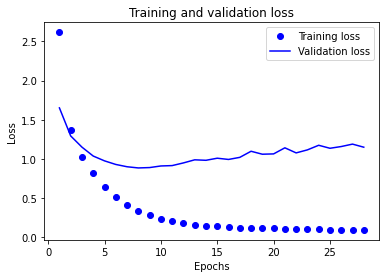

```python
loss = history.history['loss']
val_loss = history.history['val_loss']

epochs = range(1, len(loss) + 1)

plt.plot(epochs, loss, 'bo', label='Training loss')
plt.plot(epochs, val_loss, 'b', label='Validation loss')
plt.title('Training and validation loss')
plt.xlabel('Epochs')
plt.ylabel('Loss')
plt.legend()

plt.show()
```

### 에폭별 accuracy(정확도) 결과 시각화

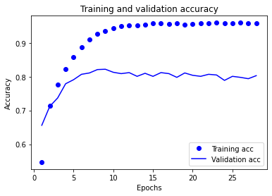

```python
plt.clf()   # 그래프를 초기화합니다

acc = history.history['accuracy']
val_acc = history.history['val_accuracy']

plt.plot(epochs, acc, 'bo', label='Training acc')
plt.plot(epochs, val_acc, 'b', label='Validation acc')
plt.title('Training and validation accuracy')
plt.xlabel('Epochs')
plt.ylabel('Accuracy')
plt.legend()

plt.show()
```

### 06 적당한 epoch으로 조정

### 모델 변경 - epochs을 변경

- 9번째 에포크 이후에 과대적합이 현상이 보임.
- 9번의 에포크로 새로운 모델 훈련과 테스트 세트에서 평가

```python
model = models.Sequential()
model.add(layers.Dense(64, activation='relu', input_shape=(10000,)))
model.add(layers.Dense(64, activation='relu'))
model.add(layers.Dense(46, activation='softmax'))

model.compile(optimizer='rmsprop',
              loss='categorical_crossentropy',
              metrics=['accuracy'])

model.fit(partial_X_train,
          partial_y_train,
          epochs=9,
          batch_size=512,
          validation_data=(X_val, y_val))
```

```
<keras.callbacks.History at 0x1f39049f1f0>
```

```python
results = model.evaluate(X_test, y_test)
print("최종 평가(loss, accuracy) : ", results)
```

```
최종 평가(loss, accuracy) :  [0.9601863026618958, 0.7938557267189026]
```

### 모델 학습 후, 테스트 데이터를 사용하여 예측

```python
pred = model.predict(X_test)
pred[0]
```

```
array([1.61659154e-05, 1.00647594e-04, 8.32144542e-06, 8.74383152e-01,
       9.08382311e-02, 1.49808810e-04, 7.12968700e-04, 3.55729717e-05,
       4.15602187e-03, 1.17137288e-05, 5.94606827e-05, 6.56019431e-04,
       2.45071802e-04, 1.55638409e-04, 9.83425416e-05, 7.67887614e-05,
       1.96631998e-03, 5.41928515e-04, 3.09917988e-04, 3.92658776e-03,
       1.53046707e-02, 5.63942769e-04, 1.01047968e-04, 4.01969271e-04,
       1.88929534e-05, 4.22453231e-05, 1.65694000e-05, 1.66216356e-04,
       8.48767580e-04, 8.33748782e-04, 1.22651923e-04, 2.72798032e-04,
       7.34142668e-05, 5.85259613e-06, 6.27420843e-04, 4.90616840e-05,
       3.93881433e-04, 4.44498291e-04, 6.11636506e-06, 9.19212936e-04,
       1.73625776e-05, 2.65926006e-04, 2.08015208e-05, 1.64218091e-05,
       1.46543789e-06, 1.61237604e-05], dtype=float32)
```

```python
# 첫번째 데이터의 확률 분포 확인
pred[0].shape
```

```
(46,)
```

```python
# softmax 활성화 함수 사용 - 46개 뉴런의 예측 확률의 합은 1이 된다(softmax)
np.sum(pred[0])
```

```
0.9999998
```

### 확률이 가장 큰 값이 예측 클래스가 된다.

```python
# 확률이 가장 큰 값을 예측 클래스로 한다.
np.argmax(pred[0])
```

```
3
```

### 06 다양한 모델(오차함수 변경)

- 정수 레이블(타켓)을 그대로 사용할 때
  - 손실함수를 sparse_categorical_crossentropy 를 사용

### 정수 레이블을 그대로 이용

```python
y_train = np.array(train_labels)
y_test = np.array(test_labels)

print(y_train.shape)

X_val = X_train[ :1000]
partial_x_train = X_train[1000:]

y_val = y_train[:1000]
partial_y_train = y_train[1000:]
```

```
(8982,)
```

```python
model = models.Sequential()
model.add(layers.Dense(64, activation='relu', input_shape=(10000,)))
model.add(layers.Dense(64, activation='relu'))
model.add(layers.Dense(46, activation='softmax'))

model.compile(optimizer='rmsprop',
              loss='sparse_categorical_crossentropy',
              metrics=['accuracy'])

model.fit(partial_X_train,
          partial_y_train,
          epochs=9,
          batch_size=512,
          validation_data=(X_val, y_val))
```

```
<keras.callbacks.History at 0x1f391881700>
```

```python
results = model.evaluate(X_test, y_test)
print("최종 평가(loss, accuracy) : ", results)
```

```
최종 평가(loss, accuracy) :  [1.003587007522583, 0.7916295528411865]
```

### 08 다양한 모델(은닉층 뉴런이 많이 작을 경우)

### 충분히 큰 중간층을 두기

- 출력층이 46차원이다. 중간층의 히든 유닛이 46개보다 적으면 안된다.

```python
model = models.Sequential()
model.add(layers.Dense(64, activation='relu', input_shape=(10000,)))
model.add(layers.Dense(64, activation='relu'))
model.add(layers.Dense(46, activation='softmax'))
```

```python
model.compile(optimizer='rmsprop',
              loss='sparse_categorical_crossentropy',
              metrics=['accuracy'])

print( partial_x_train.shape, partial_y_train.shape )

history = model.fit(partial_x_train, partial_y_train,
                    epochs=20,
                    batch_size=512,
                    validation_data=(X_val, y_val))

results = model.evaluate(X_test, y_test)
print("최종 평가(loss, accuracy) : ", results)
```

```
(7982, 10000) (7982,)
최종 평가(loss, accuracy) :  [1.1830408573150635, 0.7871772050857544]
```

### 46차원보다 훨씬 작은 중간층(예를 들어 4차원)을 두면,

```python
model = models.Sequential()
model.add(layers.Dense(64, activation='relu', input_shape=(10000,)))
model.add(layers.Dense(4, activation='relu'))
model.add(layers.Dense(46, activation='softmax'))

model.compile(optimizer='rmsprop',
              loss='sparse_categorical_crossentropy',
              metrics=['accuracy'])

history = model.fit(partial_x_train, partial_y_train,
                    epochs=20,
                    batch_size=512,
                    validation_data=(X_val, y_val))

results = model.evaluate(X_test, y_test)
print("최종 평가(loss, accuracy) : ", results)
```

```
최종 평가(loss, accuracy) :  [1.645433783531189, 0.6500445008277893]
```

### 검증 정확도가 감소

- 출력층보다 뉴런의 수가 많이 적을 경우, 검증 정확도의 감소 현상이 생길 수 있음.
- 추가 실험해보기
  - 더 크거나 작은 층을 사용해 보세요: 32개 유닛, 128개 유닛 등
  - 여기에서 두 개의 은닉층을 사용했습니다. 한 개의 은닉층이나 세 개의 은닉층을 사용해 보세요.

### (추가 공부) 데이터 섞기(np.random.shuffle)

- 데이터 섞기 후, 데이터 확인 결과 약 20% 정도 제외한 결과가 전부 다름

```python
import copy

test_labels_copy = copy.copy(test_labels)
np.random.shuffle(test_labels_copy)       # 데이터 섞기

float(np.sum(np.array(test_labels) == np.array(test_labels_copy))) / len(test_labels)
```

```
0.18699910952804988
```

### Summary

- 단일 레이블, 다중 분류 문제에서는 N개의 클래스에 대한 확률 분포를 출력하기 위해 **softmax 활성화 함수**를 사용
- 항상 범주형 크로스엔트로피를 사용
  - 이 함수는 모델이 출력한 확률 분포와 타깃 분포 사이의 거리를 최소화
- 다중 분류에서 레이블을 다루는 두가지 방법
  - 레이블을 범주형 인코딩(또는 원-핫 인코딩)으로 인코딩하고 categorical_crossentropy 손실 함수를 사용
  - 레이블을 정수로 인코딩하고 sparse_categorical_crossentropy 손실 함수를 사용